# Optimization of Bus Routes in Pangyo Techno Valleys_3

## Ⅵ. 네트워크 분석: 퍼스트마일 문제가 있는 지역을 위한 신규노선 설계 및 제안

- 앞선 분석에서는 판교 제2·3테크노밸리로의 승용차 통근량이 집중적으로 발생하는 지역을 클러스터링하고, 이들 지역과의 대중교통 연계를 위해 핵심 라스트마일 거점 4곳에서 운행되는 기존 버스 노선의 혼잡도, 우회율, 배차 간격 등의 문제를 진단하고, 노선 분리 및 배차 조정 등의 개선 방향을 제시하였음
- 하지만 일부 클러스터는 기존 라스트마일 거점과의 연계성 자체가 매우 취약하거나, 대중교통 접근이 어려운 퍼스트마일 환경에 놓여 있어 현재의 버스 노선만으로는 효과적인 커버가 어려움
- 이러한 퍼스트마일 문제는 대중교통 전환을 실질적으로 가로막는 주요 장애 요인이며, 이러한 특성을 지닌 클러스터 일부 지역에는 신규 노선을 통해 직접적인 연결성을 제공하는 것이 필요함  
  ➡ 이에 본 절에서는 승용차 통근 수요가 높은 클러스터들 중, 퍼스트마일 접근성이 낮아 대중교통 전환이 특히 어려운 지역을 중심으로 신규 노선 도입의 필요성을 제기하고자 함. 이를 위해 다익스트라 알고리즘을 활용하여 주요 수요지와 판교 제2·3테크노밸리를 연결하는 최적 경로를 도출하고, 대중교통의 퍼스트마일 연계를 보완할 수 있는 신규 노선 구조를 제안하였음.

<그림 9>은 본 분석에 활용한 데이터셋과 분석 과정을 요약한 흐름도이다. 이어지는 단락에서 각 분석 단계에 대해 자세히 설명하겠다.

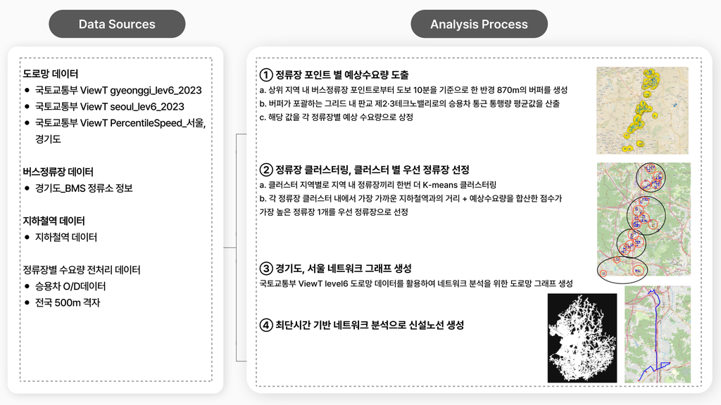

**<그림 9>** 신규노선 설계를 위한 분석 파이프라인

## 1. 노선 설계 목표

신규 노선 설계 목표

| 수요 반영 | 제2테크노밸리로의 통근 수요가 높은 그리드 지역 및 정류장을 우선적으로 고려 |
| --- | --- |
| 퍼스트/라스트 마일 보장 | 통근 수요량이 많은 정류장 중에서도 지하철 역과 거리가 멀어 퍼스마일 문제가 있는 정류장을 우선 선정, 최종 정류장에서 하차한 후에도 테크노밸리 내 주요 업무지까지 무리 없이 이동할 수 있도록 운행 노선 설계 |
| 우회율 최소화 | 불필요한 정류장 경유를 줄여 경로 길이 단축 및 운행 효율 극대화 |

## 2. 정류장 포인트 별 예상 수요량 도출

- 수요를 반영한 노선 생성을 위해 우선 각 정류장 별 판교 테크노밸리로의 통근 수요량을 포함하는 데이터셋을 구축
- 4개의 상위 클러스터 지역 내 버스정류장 포인트로부터 도보 10분을 기준으로 한 반경 870m의 버퍼를 생성한 후 각 버퍼가 포괄하는 그리드 내 판교 제2·3테크노밸리로의 승용차 통근 통행량의 평균값을 산출함으로써 각 정류장별 예상 수요량을 도출하였고, 이를 제2·3테크노밸리로의 잠재적 통근 수요량으로 상정

### 2-1. 상위 그리드 내 정류장만 추출

```python
from shapely import wkt
from shapely.geometry import Point
```

```python
high_traffic = gpd.read_file('./data/high_traffic.geojson') # 상위 그리드 데이터 불러오기
high_traffic.head()
```

|  | SPO_NO_CD | 8_평균 | breaks | lon | lat | cluster | geometry |
| --- | --- | --- | --- | --- | --- | --- | --- |
| 0 | 다사61a18a | 10.655617 | 3 | 127.062985 | 37.262343 | 6 | POLYGON ((127.06018 37.26008, 127.06015 37.264... |
| 1 | 다사62b18a | 33.222675 | 4 | 127.079901 | 37.262404 | 6 | POLYGON ((127.07709 37.26014, 127.07707 37.264... |
| 2 | 다사70a39b | 11.149093 | 3 | 127.163619 | 37.456469 | 1 | POLYGON ((127.1608 37.45421, 127.16078 37.4587... |
| 3 | 다사64b25a | 17.703600 | 3 | 127.102124 | 37.325578 | 0 | POLYGON ((127.09931 37.32332, 127.09929 37.327... |
| 4 | 다사61b22a | 11.436200 | 3 | 127.068418 | 37.298418 | 6 | POLYGON ((127.06561 37.29615, 127.06558 37.300... |

```python
# 정류장 데이터 불러오기
station = pd.read_csv('./data/경기도_BMS정류소정보.csv', encoding='cp949')
station.head(1)
```

|  | 정류장아이디 | 정류장명 | Y좌표 | X좌표 | GPSX좌표 | GPSY좌표 | 링크아이디 | 정류장유형 | 환승정류장유무 | 중앙차로여부 | ... | 행정동코드 | 권역코드 | 사용구분 | 정류장중국어명 | 정류장일본어명 | 정류장베트남명 | DRT유무 | 정류장유형명 | 환승역타입명 | 표지판유형명 |
| --- | --- | --- | --- | --- | --- | --- | --- | --- | --- | --- | --- | --- | --- | --- | --- | --- | --- | --- | --- | --- | --- |
| 0 | 101000067 | 을지로5가.중부시장 | 200031.5896 | 451600.81964 | NaN | NaN | 1010008000 | 0 | NaN | N | ... | 1114060500 | 101 | Y | 乙支路5街·中部市？ | ウルチロ5ガ、中部市場 | Euljiro-ga 5. Ch？ Jungbu | N | 미지정 | NaN | NaN |

1 rows × 28 columns

```python
station.columns
```

```
Index(['정류장아이디', '정류장명', 'Y좌표', 'X좌표', 'GPSX좌표', 'GPSY좌표', '링크아이디', '정류장유형',
       '환승정류장유무', '중앙차로여부', '정류장영문명', 'ARS아이디', '기관코드', '데이터표출유무', '등록아이디',
       '등록일자', '비고', '표지판유형', '행정동코드', '권역코드', '사용구분', '정류장중국어명', '정류장일본어명',
       '정류장베트남명', 'DRT유무', '정류장유형명', '환승역타입명', '표지판유형명'],
      dtype='object')
```

```python
station = station[['정류장아이디', '정류장명', 'Y좌표', 'X좌표']] # 필요한 컬럼만 추출
```

```python
station_gdf = gpd.GeoDataFrame(station,
                                geometry=gpd.points_from_xy(station.Y좌표, station.X좌표),
                                crs='EPSG:5174'
                               ) # geodataframe으로 변경
station_gdf
```

|  | 정류장아이디 | 정류장명 | Y좌표 | X좌표 | geometry |
| --- | --- | --- | --- | --- | --- |
| 0 | 101000067 | 을지로5가.중부시장 | 200031.58960 | 451600.81964 | POINT (200031.59 451600.82) |
| 1 | 101000073 | 을지로6가.국립중앙의료원 | 200449.15129 | 451582.48627 | POINT (200449.151 451582.486) |
| 2 | 101000079 | 성동공업고등학교(무궁화회관) | 201327.91042 | 451789.22523 | POINT (201327.91 451789.225) |
| 3 | 101000081 | 신당역.중앙시장앞 | 201586.10689 | 451498.86157 | POINT (201586.107 451498.862) |
| 4 | 101000083 | 성동고등학교 | 201878.90898 | 451480.65669 | POINT (201878.909 451480.657) |
| ... | ... | ... | ... | ... | ... |
| 19995 | 234000888 | 상림입구 | 227493.13344 | 424419.13719 | POINT (227493.133 424419.137) |
| 19996 | 234000890 | 시골집 | 218930.38706 | 439728.05585 | POINT (218930.387 439728.056) |
| 19997 | 234000891 | 우창물류 | 228579.92376 | 422648.59306 | POINT (228579.924 422648.593) |
| 19998 | 234000893 | 유리공장앞 | 218484.19889 | 427403.81650 | POINT (218484.199 427403.816) |
| 19999 | 234000895 | 유사1리마을회관 | 237543.57581 | 430682.48912 | POINT (237543.576 430682.489) |

20000 rows × 5 columns

```python
station_gdf.crs # 좌표계 확인
```

```
<Projected CRS: EPSG:5174>
Name: Korean 1985 / Modified Central Belt
Axis Info [cartesian]:
- X[north]: Northing (metre)
- Y[east]: Easting (metre)
Area of Use:
- name: Republic of Korea (South Korea) - between 126°E and 128°E - mainland and nearshore.
- bounds: (126.0, 33.96, 128.0, 38.33)
Coordinate Operation:
- name: Korea Modified Central Belt
- method: Transverse Mercator
Datum: Korean Datum 1985
- Ellipsoid: Bessel 1841
- Prime Meridian: Greenwich
```

```python
high_traffic.crs # 좌표계 확인
```

```
<Geographic 2D CRS: EPSG:4326>
Name: WGS 84
Axis Info [ellipsoidal]:
- Lat[north]: Geodetic latitude (degree)
- Lon[east]: Geodetic longitude (degree)
Area of Use:
- name: World.
- bounds: (-180.0, -90.0, 180.0, 90.0)
Datum: World Geodetic System 1984 ensemble
- Ellipsoid: WGS 84
- Prime Meridian: Greenwich
```

```python
# 상위 그리드와 교차하는 정류장만 추출
station_gdf = station_gdf.to_crs('EPSG:4326') # high_traffic 좌표계와 통일

station_filtered = gpd.sjoin(
    station_gdf,
    high_traffic,
    predicate='intersects',  # 교차하는지 확인 (내부 포함 + 걸쳐 있는 경우)
    how='inner'              # 겹치는 것만 남김
)

station_filtered.head()
```

|  | 정류장아이디 | 정류장명 | Y좌표 | X좌표 | geometry | index_right | SPO_NO_CD | 8_평균 | breaks | lon | lat | cluster |
| --- | --- | --- | --- | --- | --- | --- | --- | --- | --- | --- | --- | --- |
| 3150 | 206000020 | 정자사거리 | 209769.83257 | 430531.74283 | POINT (127.11109 37.37681) | 37 | 다사65b30b | 13.452150 | 3 | 127.113157 | 37.375191 | 3 |
| 3151 | 206000022 | 신기초등학교 | 209672.89454 | 429563.20379 | POINT (127.10999 37.36808) | 59 | 다사65a29b | 12.096035 | 3 | 127.107557 | 37.366159 | 3 |
| 3152 | 206000024 | 분당중학교 | 209676.00000 | 428821.00000 | POINT (127.11001 37.36139) | 24 | 다사65a29a | 9.987840 | 3 | 127.107580 | 37.361652 | 3 |
| 3637 | 206000084 | KT.주택전시관 | 209904.02292 | 428645.07453 | POINT (127.11258 37.35981) | 46 | 다사65b29a | 15.467158 | 3 | 127.113226 | 37.361670 | 3 |
| 4364 | 205000120 | (구)성남동주민센터 | 211778.79843 | 436868.66356 | POINT (127.13388 37.43388) | 16 | 다사67b37a | 11.615423 | 3 | 127.135462 | 37.433851 | 1 |

```python
# station_filtered.to_file('./data/station_filtered.geojson')
```

```python
m = folium.Map(location=[37.3576, 127.12305], zoom_start=11) # 필터링 된 정류장 시각적으로 확인
folium.GeoJson(
    high_traffic,
    name='혼잡 구역 (Polygon)',
    style_function=lambda feature: {
        'fillColor': '#ff7800',
        'color': 'black',
        'weight': 1,
        'fillOpacity': 0.3,
    },
    tooltip=folium.GeoJsonTooltip(fields=['SPO_NO_CD', '8_평균', 'cluster'])
).add_to(m)

for _, row in station_filtered.iterrows():
    folium.CircleMarker(
        location=[row.geometry.y, row.geometry.x],  # 위도, 경도 순서
        radius=1,
        color='blue',
        fill=True,
        fill_opacity=0.7,
        popup=row['정류장명']
    ).add_to(m)

folium.LayerControl().add_to(m)

m
```

Make this Notebook Trusted to load map: File -> Trust Notebook

[interactive chart not shown]

### 2-2. 버퍼 분석 : 정류장별 예상 수요량 산출

a. 상위 지역 내 버스정류장 포인트로부터 도보 10분을 기준으로 한 반경 870m 버퍼를 생성  
b. 버퍼가 포괄하는 그리드 내 판교 제2﹒3테크노밸리로의 승용차 통근 통행량 평균값을 산출  
c. 해당 값을 각 정류장별 예상 수요량으로 상정

```python
# 버퍼 분석을 위해 미터 단위가 사용 가능한 투영 좌표계로 변환
gdf_grid_proj = high_traffic.to_crs(epsg=5186)
gdf_stop_proj = station_filtered.to_crs(epsg=5186)
```

```python
# 도보 10분 기준 870m 버퍼 생성
gdf_stop_proj['buffer'] = gdf_stop_proj.geometry.buffer(870)
```

```python
gdf_stop_proj.head()
```

|  | 정류장아이디 | 정류장명 | Y좌표 | X좌표 | geometry | index_right | SPO_NO_CD | 8_평균 | breaks | lon | lat | cluster | buffer |
| --- | --- | --- | --- | --- | --- | --- | --- | --- | --- | --- | --- | --- | --- |
| 3150 | 206000020 | 정자사거리 | 209769.83257 | 430531.74283 | POINT (209839.701 530837.279) | 37 | 다사65b30b | 13.452150 | 3 | 127.113157 | 37.375191 | 3 | POLYGON ((210709.701 530837.279, 210705.512 53... |
| 3151 | 206000022 | 신기초등학교 | 209672.89454 | 429563.20379 | POINT (209742.779 529868.746) | 59 | 다사65a29b | 12.096035 | 3 | 127.107557 | 37.366159 | 3 | POLYGON ((210612.779 529868.746, 210608.59 529... |
| 3152 | 206000024 | 분당중학교 | 209676.00000 | 428821.00000 | POINT (209745.897 529126.548) | 24 | 다사65a29a | 9.987840 | 3 | 127.107580 | 37.361652 | 3 | POLYGON ((210615.897 529126.548, 210611.707 52... |
| 3637 | 206000084 | KT.주택전시관 | 209904.02292 | 428645.07453 | POINT (209973.921 528950.628) | 46 | 다사65b29a | 15.467158 | 3 | 127.113226 | 37.361670 | 3 | POLYGON ((210843.921 528950.628, 210839.731 52... |
| 4364 | 205000120 | (구)성남동주민센터 | 211778.79843 | 436868.66356 | POINT (211848.549 537174.181) | 16 | 다사67b37a | 11.615423 | 3 | 127.135462 | 37.433851 | 1 | POLYGON ((212718.549 537174.181, 212714.359 53... |

```python
gdf_buffer = gdf_stop_proj.copy() # 버퍼 지오메트리만 남기기 위해 데이터프레임 복사
gdf_buffer = gdf_buffer.drop(columns=['geometry'])  # 기존 지오메트리 컬럼은 삭제
gdf_buffer = gdf_buffer.rename(columns={'buffer':'geometry'}) # 버퍼를 지오메트리로 변경
gdf_buffer.head(2)
```

|  | 정류장아이디 | 정류장명 | Y좌표 | X좌표 | index_right | SPO_NO_CD | 8_평균 | breaks | lon | lat | cluster | geometry |
| --- | --- | --- | --- | --- | --- | --- | --- | --- | --- | --- | --- | --- |
| 3150 | 206000020 | 정자사거리 | 209769.83257 | 430531.74283 | 37 | 다사65b30b | 13.452150 | 3 | 127.113157 | 37.375191 | 3 | POLYGON ((210709.701 530837.279, 210705.512 53... |
| 3151 | 206000022 | 신기초등학교 | 209672.89454 | 429563.20379 | 59 | 다사65a29b | 12.096035 | 3 | 127.107557 | 37.366159 | 3 | POLYGON ((210612.779 529868.746, 210608.59 529... |

```python
# 각 버퍼가 포함하는 그리드의 통행량 평균 계산
mean_traffic = [] # 각 버퍼 안에 포함된 그리드들의 평균 통행량을 저장할 리스트
for buffer in gdf_buffer.geometry: # gdf_buffer의 각 geometry(버퍼)에 대해 반복
    contained_grids = gdf_grid_proj[gdf_grid_proj.intersects(buffer)] # gdf_grid_proj에서 해당 버퍼와 교차하는 그리드만 필터링
    mean_val = contained_grids['8_평균'].mean() # 포함된 grid 셀들에서 '8_평균' 컬럼의 평균값을 계산
    mean_traffic.append(mean_val) # 계산한 평균값을 mean_traffic 리스트에 추가

# 정류장별 예상수요량 컬럼 추가
gdf_stop_proj['예상수요량'] = mean_traffic
gdf_stop_proj.head(2)
```

|  | 정류장아이디 | 정류장명 | Y좌표 | X좌표 | geometry | index_right | SPO_NO_CD | 8_평균 | breaks | lon | lat | cluster | buffer | 예상수요량 |
| --- | --- | --- | --- | --- | --- | --- | --- | --- | --- | --- | --- | --- | --- | --- |
| 3150 | 206000020 | 정자사거리 | 209769.83257 | 430531.74283 | POINT (209839.701 530837.279) | 37 | 다사65b30b | 13.452150 | 3 | 127.113157 | 37.375191 | 3 | POLYGON ((210709.701 530837.279, 210705.512 53... | 13.176429 |
| 3151 | 206000022 | 신기초등학교 | 209672.89454 | 429563.20379 | POINT (209742.779 529868.746) | 59 | 다사65a29b | 12.096035 | 3 | 127.107557 | 37.366159 | 3 | POLYGON ((210612.779 529868.746, 210608.59 529... | 14.609423 |

```python
# 계산 용이하게 하기 위하여 지역클러스터별로 데이터프레임 4개 분리

# 클러스터 0번
cluster_detail_0 = gdf_stop_proj[gdf_stop_proj['cluster'] == 0]

# 클러스터 1번
cluster_detail_1 = gdf_stop_proj[gdf_stop_proj['cluster'] == 1]

# 클러스터 3번
cluster_detail_3 = gdf_stop_proj[gdf_stop_proj['cluster'] == 3]

# 클러스터 6번
cluster_detail_6 = gdf_stop_proj[gdf_stop_proj['cluster'] == 6]
```

## 3. 정류장 클러스터링 : 클러스터별 우선 정류장 선정

a. 클러스터 지역별로 지역 내 정류장끼리 한번 더 K-means 클러스터링  
b. 각 정류장 클러스터 내에서 가장 가까운 지하철역과의 거리 + 예상 수요량을 합산한 점수가 가장 높은 정류장 1개를 우선 정류장으로 선정

#### 클러스터0 : 최적의 k = 5

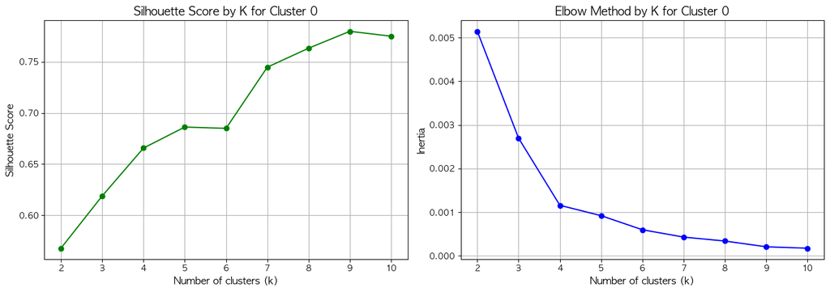

```python
data_0 = cluster_detail_0[['lon', 'lat']].values  # 좌표만 numpy array 형태로 추출

silhouette_scores_0 = []
inertia_scores_0 = []
K_range = range(2, 11)

for k in K_range:
    model = KMeans(n_clusters=k, random_state=10)
    labels = model.fit_predict(data_0)
    silhouette_scores_0.append(silhouette_score(data_0, labels))
    inertia_scores_0.append(model.inertia_)

# 1x2 subplot 생성
fig, axes = plt.subplots(1, 2, figsize=(14, 5))

# 실루엣 점수 시각화
axes[0].plot(K_range, silhouette_scores_0, marker='o', color='green')
axes[0].set_title('Silhouette Score by K for Cluster 0', fontsize=14)
axes[0].set_xlabel('Number of clusters (k)', fontsize=12)
axes[0].set_ylabel('Silhouette Score', fontsize=12)
axes[0].grid(True)

# 엘보우 (Inertia) 시각화
axes[1].plot(K_range, inertia_scores_0, marker='o', color='blue')
axes[1].set_title('Elbow Method by K for Cluster 0', fontsize=14)
axes[1].set_xlabel('Number of clusters (k)', fontsize=12)
axes[1].set_ylabel('Inertia', fontsize=12)
axes[1].grid(True)

plt.tight_layout()
plt.show()
```

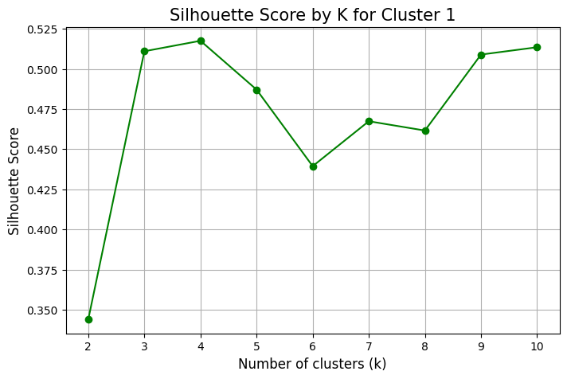

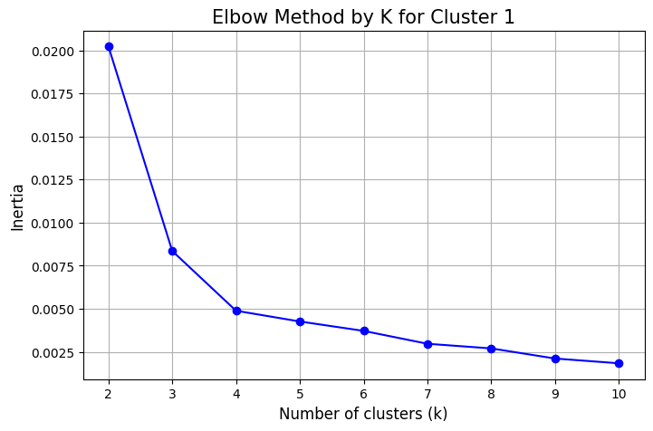

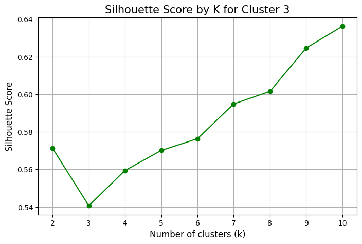

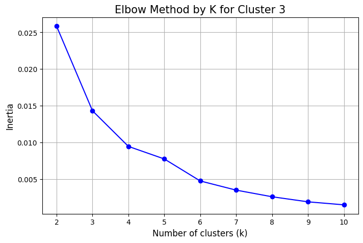

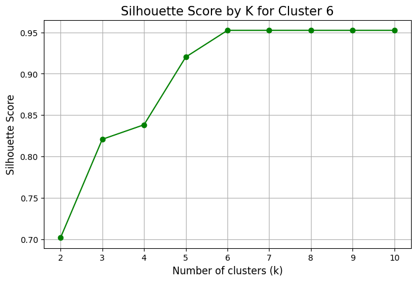

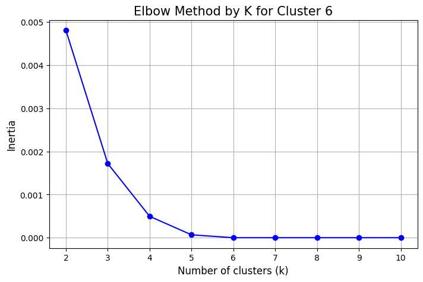

통행량 상위 지역별로 지역 내 정류장들을 다시한번 클러스터링 하였다. 최적의 K는 실루엣계수와 엘보우기법을 바탕으로 결정하였다.

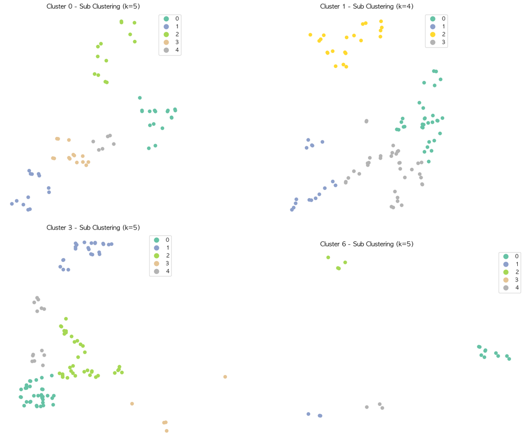

```python
from sklearn.preprocessing import StandardScaler

# 클러스터별 데이터프레임과 최적 k값, 클러스터 번호를 리스트로 묶음
cluster_details = [cluster_detail_0, cluster_detail_1, cluster_detail_3, cluster_detail_6]
k_values = [5, 4, 5, 5]
cluster_ids = [0, 1, 3, 6]

# 결과를 저장할 리스트
updated_clusters = []

# 2x2 subplot 생성
fig, axes = plt.subplots(nrows=2, ncols=2, figsize=(16, 12))  # 크기 조정 가능
axes = axes.flatten()  # 2차원 배열을 1차원으로 펼쳐서 반복문에서 사용하기 편하게

for i, (df, k, cluster_id) in enumerate(zip(cluster_details, k_values, cluster_ids)):
    data = df[['lon', 'lat']]
    scaler = StandardScaler()
    data_scaled = scaler.fit_transform(data)

    model = KMeans(n_clusters=k, random_state=10)
    labels = model.fit_predict(data_scaled)

    df = df.copy()
    df['sub_cluster'] = labels # 정류장의 클러스터를 sub_cluster로
    updated_clusters.append(df)

    # 각 subplot에 그리기
    df.plot(column='sub_cluster', categorical=True, legend=True, cmap='Set2', ax=axes[i])
    axes[i].set_title(f'Cluster {cluster_id} - Sub Clustering (k={k})', fontsize=12)
    axes[i].axis('off')

# 전체 플롯 여백 조정
plt.tight_layout()
plt.show()

# 결과 분할 저장
cluster_detail_0, cluster_detail_1, cluster_detail_3, cluster_detail_6 = updated_clusters
```

```python
gdf_all_stops = pd.concat([cluster_detail_0, cluster_detail_1, cluster_detail_3, cluster_detail_6], ignore_index=True) # 모든 클러스터 다시 병합
```

## 4. 정류장 클러스터별 최우선 정류장 도출

a. 각 정류장 클러스터 내에서 가장 가까운 지하철역과의 거리와 예상 수요량을 정규화  
b. 노선 설계 목적이 퍼스트마일 문제가 있는 지역을 위함이었기 때문에 가장 가까운 지하철역과의 거리 점수에는 가중치를 1.5 곱해주었음  
c. 버스정류장 클러스터별로 지하철역과의 거리*1.5 + 예상수요량 값이 가장 높은 정류장 1개를 우선 정류장으로 선정

```python
df_subway = pd.read_csv('/Users/jiyeonhwang/Downloads/버퍼 분석/subway.csv') # 지하철역 csv 파일 불러오기
df_subway
```

|  | 아이디 | 선명 | 역명 | Latitude | Longtitude |
| --- | --- | --- | --- | --- | --- |
| 0 | 1 | 1호선 | 영등포 | 37.515923 | 126.907373 |
| 1 | 2 | 1호선 | 오류동 | 37.495264 | 126.844977 |
| 2 | 3 | 1호선 | 오산 | 37.146431 | 127.066834 |
| 3 | 4 | 1호선 | 오산대 | 37.168054 | 127.063432 |
| 4 | 5 | 1호선 | 온수 | 37.492280 | 126.823998 |
| ... | ... | ... | ... | ... | ... |
| 266 | 267 | 경강 | 이매 | 37.393995 | 127.128231 |
| 267 | 268 | 경강 | 이천 | 37.264549 | 127.442234 |
| 268 | 269 | 경강 | 초월 | 37.373882 | 127.299036 |
| 269 | 270 | 경강 | 판교 | 37.392084 | 127.109167 |
| 270 | 271 | 경강 | 성남 | 37.394728 | 127.119418 |

271 rows × 5 columns

```python
gdf_subway = gpd.GeoDataFrame(df_subway,
                                geometry=gpd.points_from_xy(df_subway.Longtitude, df_subway.Latitude),
                                crs='EPSG:4326'
                               )
gdf_subway.head(3)
```

|  | 아이디 | 선명 | 역명 | Latitude | Longtitude | geometry |
| --- | --- | --- | --- | --- | --- | --- |
| 0 | 1 | 1호선 | 영등포 | 37.515923 | 126.907373 | POINT (126.90737 37.51592) |
| 1 | 2 | 1호선 | 오류동 | 37.495264 | 126.844977 | POINT (126.84498 37.49526) |
| 2 | 3 | 1호선 | 오산 | 37.146431 | 127.066834 | POINT (127.06683 37.14643) |

```python
import numpy as np

gdf_all_stops = gdf_all_stops.to_crs(epsg=4326) # 다시 병합된 정류장 데이터도 위경도 기준 좌표계로 변환

# 지하철역 좌표 추출
subway_coords = np.array(list(zip(gdf_subway.geometry.x, gdf_subway.geometry.y))) # 경위도 쌍을 만든 후 리스트로 변환한 다음 넘파이 배열로 변환

# 정류장별로 가장 가까운 지하철역까지의 거리 계산 함수 정의
def get_min_distance(point, subway_coords):
    stop_coord = (point.y, point.x) # 정류장들의 지오메트리로부터 좌표 추출
    distances = [haversine(stop_coord, (lat, lon)) for lon, lat in subway_coords] # 위경도를 기반으로 지구 곡률을 고려한 거리를 계산해주는 함수 harversine
    return min(distances) # 가장 가까운 지하철역까지의 거리

# 정의한 함수를 이용하여 정류장마다 가장 가까운 지하철역까지의 거리를 km로 구해서 새 열에 저장
gdf_all_stops['subway_dist_km'] = gdf_all_stops['geometry'].apply(lambda x: get_min_distance(x, subway_coords))
gdf_all_stops.head(3)
```

|  | 정류장아이디 | 정류장명 | Y좌표 | X좌표 | geometry | index_right | SPO_NO_CD | 8_평균 | breaks | lon | lat | cluster | buffer | 예상수요량 | sub_cluster | subway_dist_km |
| --- | --- | --- | --- | --- | --- | --- | --- | --- | --- | --- | --- | --- | --- | --- | --- | --- |
| 0 | 206000221 | 동원동 | 208925.32681 | 427060.54540 | POINT (127.10152 37.34554) | 23 | 다사64b27a | 11.695185 | 3 | 127.102029 | 37.343606 | 0 | POLYGON ((209865.258 527366.095, 209861.068 52... | 11.962535 | 2 | 0.941141 |
| 1 | 206000222 | 미금역.2001아울렛 | 209397.03797 | 427578.43939 | POINT (127.10685 37.3502) | 7 | 다사65a27b | 13.240870 | 3 | 127.107650 | 37.348131 | 0 | POLYGON ((210336.957 527883.993, 210332.768 52... | 12.468027 | 2 | 0.241732 |
| 2 | 206000228 | 미금역.2001아울렛 | 209399.14503 | 427551.10468 | POINT (127.10687 37.34996) | 7 | 다사65a27b | 13.240870 | 3 | 127.107650 | 37.348131 | 0 | POLYGON ((210339.064 527856.658, 210334.875 52... | 12.468027 | 2 | 0.259232 |

```python
df_cluster = {} # 클러스터별로 데이터 프레임 잘라서 딕셔너리에 넣기
cluster = [0, 1, 3, 6]

for i in cluster:
    df = gdf_all_stops[gdf_all_stops['cluster'] == i]
    df_cluster[f'df_{i}'] = df

df_cluster.keys()
```

```
dict_keys(['df_0', 'df_1', 'df_3', 'df_6'])
```

```python
# 우리는 지역별로 정류장 클러스터에서 각각 하나씩 정류장을 뽑을거임
# 기준은 해당 정류장의 테크노밸리로의 통근 수요량 + 거리 점수 계산해서 우리는 이 점수가 높은 정류장을 뽑는 것이 목표임
# 테크노밸리로의 통근 수요량이 높으면서 가장 가까운 지하철 역까지의 거리가 높을수록 퍼스트마일 보장이 필요한 곳이기 때문에
# 현재 수요량컬럼이랑 거리 컬럼이랑 데이터 스케일 차이가 큼 따라서 점수 계산하기 위해서 데이터 스케일링
from sklearn.preprocessing import MinMaxScaler

for df in df_cluster.values():
    cols_to_scale = ['예상수요량', 'subway_dist_km']
    scaler = MinMaxScaler()
    df[cols_to_scale] = scaler.fit_transform(df[cols_to_scale])

df_cluster['df_0'].head(3) # 정규화 된거 확인
```

|  | 정류장아이디 | 정류장명 | Y좌표 | X좌표 | geometry | index_right | SPO_NO_CD | 8_평균 | breaks | lon | lat | cluster | buffer | 예상수요량 | sub_cluster | subway_dist_km |
| --- | --- | --- | --- | --- | --- | --- | --- | --- | --- | --- | --- | --- | --- | --- | --- | --- |
| 0 | 206000221 | 동원동 | 208925.32681 | 427060.54540 | POINT (127.10152 37.34554) | 23 | 다사64b27a | 11.695185 | 3 | 127.102029 | 37.343606 | 0 | POLYGON ((209865.258 527366.095, 209861.068 52... | 0.019000 | 2 | 0.294578 |
| 1 | 206000222 | 미금역.2001아울렛 | 209397.03797 | 427578.43939 | POINT (127.10685 37.3502) | 7 | 다사65a27b | 13.240870 | 3 | 127.107650 | 37.348131 | 0 | POLYGON ((210336.957 527883.993, 210332.768 52... | 0.078871 | 2 | 0.005717 |
| 2 | 206000228 | 미금역.2001아울렛 | 209399.14503 | 427551.10468 | POINT (127.10687 37.34996) | 7 | 다사65a27b | 13.240870 | 3 | 127.107650 | 37.348131 | 0 | POLYGON ((210339.064 527856.658, 210334.875 52... | 0.078871 | 2 | 0.012945 |

```python
# 해당 정류장의 테크노밸리로의 통근 수요량 + 거리 점수 계산
# 테크노밸리로의 통근 수요량이 높으면서 가장 가까운 지하철 역까지의 거리가 높을수록 퍼스트마일 보장이 필요한 곳이기 때문에

for df in df_cluster.values():
    df['score'] = df['예상수요량'] + (df['subway_dist_km']*1.5) # 퍼스트마일 보장이 어려운 곳이 타겟이니까 우선을 주기 위해서 거리에는 1.5 가중치

df_cluster['df_0'].head(3)
```

|  | 정류장아이디 | 정류장명 | Y좌표 | X좌표 | geometry | index_right | SPO_NO_CD | 8_평균 | breaks | lon | lat | cluster | buffer | 예상수요량 | sub_cluster | subway_dist_km | score |
| --- | --- | --- | --- | --- | --- | --- | --- | --- | --- | --- | --- | --- | --- | --- | --- | --- | --- |
| 0 | 206000221 | 동원동 | 208925.32681 | 427060.54540 | POINT (127.10152 37.34554) | 23 | 다사64b27a | 11.695185 | 3 | 127.102029 | 37.343606 | 0 | POLYGON ((209865.258 527366.095, 209861.068 52... | 0.019000 | 2 | 0.294578 | 0.460867 |
| 1 | 206000222 | 미금역.2001아울렛 | 209397.03797 | 427578.43939 | POINT (127.10685 37.3502) | 7 | 다사65a27b | 13.240870 | 3 | 127.107650 | 37.348131 | 0 | POLYGON ((210336.957 527883.993, 210332.768 52... | 0.078871 | 2 | 0.005717 | 0.087446 |
| 2 | 206000228 | 미금역.2001아울렛 | 209399.14503 | 427551.10468 | POINT (127.10687 37.34996) | 7 | 다사65a27b | 13.240870 | 3 | 127.107650 | 37.348131 | 0 | POLYGON ((210339.064 527856.658, 210334.875 52... | 0.078871 | 2 | 0.012945 | 0.098288 |

```python
top_score_stops = {} # 빈 딕셔너리 생성

for k, v in df_cluster.items():
    idx = v.groupby('sub_cluster')['score'].idxmax() # sub_cluster별로 score가 가장 높은 행의 인덱스를 구하기
    df = v.loc[idx].reset_index(drop=True) # 해당 인덱스를 이용해 원본 데이터프레임에서 추출
    top_score_stops[k] = df

top_score_stops.keys()
```

```
dict_keys(['df_0', 'df_1', 'df_3', 'df_6'])
```

```python
top_score_stops['df_0'].explore()
```

Make this Notebook Trusted to load map: File -> Trust Notebook

[interactive chart not shown]

```python
top_score_stops['df_1'].explore()
```

Make this Notebook Trusted to load map: File -> Trust Notebook

[interactive chart not shown]

```python
top_score_stops['df_3'].explore()
```

Make this Notebook Trusted to load map: File -> Trust Notebook

[interactive chart not shown]

```python
top_score_stops['df_6'].explore()
```

Make this Notebook Trusted to load map: File -> Trust Notebook

[interactive chart not shown]

```python
top_score_stops['df_6'] = top_score_stops['df_6'].iloc[[0, 1, 3, 4],:] # 너무 먼 정류장 제외
```

```python
top_score_stops['df_0'] = top_score_stops['df_0'].drop('buffer', axis = 1)
top_score_stops['df_1'] = top_score_stops['df_1'].drop('buffer', axis = 1)
top_score_stops['df_3'] = top_score_stops['df_3'].drop('buffer', axis = 1)
top_score_stops['df_6'] = top_score_stops['df_6'].drop('buffer', axis = 1)
```

```python
# top_score_stops['df_0'].to_file('./data/클러스터0_최종정류장.geojson')
# top_score_stops['df_1'].to_file('./data/클러스터1_최종정류장.geojson')
# top_score_stops['df_3'].to_file('./data/클러스터3_최종정류장.geojson')
# top_score_stops['df_6'].to_file('./data/클러스터6_최종정류장.geojson')
```

## 5. 신설노선 생성

발표에서는 대표로 클러스터 0 지역만 진행

### 5-1. 네트워크 그래프 생성

국토교통부 ViewT leavel6 도로망 데이터를 활용하여 네트워크 분석을 위한 도로망 그래프 생성

```python
import networkx as nx
import osmnx as ox
from tqdm import tqdm


# 노드 파일 두 개 읽기
nodes_seoul = gpd.read_file('./data/네트워크분석/seoul_lev6_2023/seoul_node_lev6_2023.shp', encoding='cp949')
nodes_gg = gpd.read_file('./data/네트워크분석/gyeonggi_lev6_2023/gyeonggi_node_lev6_2023.shp', encoding='cp949')

# 링크 파일 두 개 읽기
edges_seoul = gpd.read_file('./data/네트워크분석/seoul_lev6_2023/seoul_link_lev6_2023.shp', encoding='cp949')
edges_gg = gpd.read_file('./data/네트워크분석/gyeonggi_lev6_2023/gyeonggi_link_lev6_2023.shp', encoding='cp949')

# 각각 concat으로 결합
nodes_viewt = gpd.GeoDataFrame(pd.concat([nodes_seoul, nodes_gg], ignore_index=True))
edges_viewt = gpd.GeoDataFrame(pd.concat([edges_seoul, edges_gg], ignore_index=True))
```

```python
emd_gdf = gpd.read_file('./data/emd/emd.shp')
emd_gdf['ADM_CD'] = emd_gdf['ADM_CD'].astype(str)
emd_gdf = emd_gdf.dissolve(by='BASE_DATE')
```

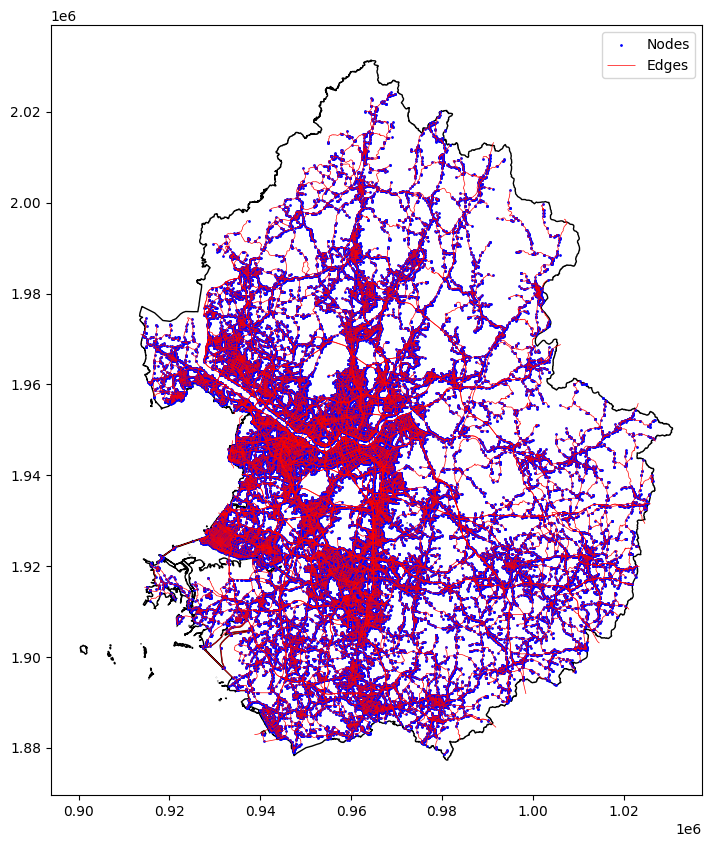

```python
fig, ax = plt.subplots(figsize=(10, 10))
emd_gdf.plot(ax=ax, facecolor='none', edgecolor='black')
nodes_viewt.plot(ax=ax, color='blue', markersize=1, label='Nodes')
edges_viewt.plot(ax=ax, color='red', linewidth=0.5, label='Edges')

plt.legend()
```

```python
nodes_gdf = nodes_viewt.copy()
nodes_gdf['node_id'] = nodes_gdf['node_id'].astype(int) # 소수점 제거
nodes_gdf['node_id'] = nodes_gdf['node_id'].astype(str) # 문자열로 변경
nodes_gdf['node_type'] = nodes_gdf['node_type'].astype(int) # 소수점 제거
nodes_gdf['node_type'] = nodes_gdf['node_type'].astype(str) # 문자열로 변경

# 노드 포인트 지오메트리에서 x, y 좌표 뽑기
nodes_gdf['y'] = nodes_gdf['geometry'].y
nodes_gdf['x'] = nodes_gdf['geometry'].x
nodes_gdf = nodes_gdf[['node_id', 'node_type', 'geometry', 'x', 'y']] # 필요한 컬럼만 추출

# 인덱스를 node_id로 설정
nodes_gdf = nodes_gdf.set_index('node_id')

nodes_gdf.head(3)
```

| node_id | node_type | geometry | x | y |
| --- | --- | --- | --- | --- |
| 201345 | 101 | POINT (940053.394 1943848.591) | 940053.394447 | 1.943849e+06 |
| 201391 | 101 | POINT (943106.602 1943217.947) | 943106.602350 | 1.943218e+06 |
| 201392 | 101 | POINT (943109.786 1943171.169) | 943109.786484 | 1.943171e+06 |

> 코드 실행 시간을 감안하여 위 작업이 이미 완료된 데이터를 아래에서 불러오도록 하겠다.

```
edges_gdf = gpd.GeoDataFrame()

for idx, row in tqdm(edges_viewt.iterrows(), total=edges_viewt.shape[0]):
    if row['oneway'] == 0: # If the road is two-way, duplicate the row with reversed geometry
        # Create a new row with non-reversed geometry
        edges_gdf = pd.concat([gpd.GeoDataFrame({'link_id': row['up_v_link'],
                                            'f_node': row['up_f_node'],
                                            't_node': row['up_t_node'],
                                            'max_speed': row['max_speed'],
                                            'road_name': row['road_name'],
                                            'road_rank': row['road_rank'],
                                            'link_type': row['link_type'],
                                            'geometry': row['geometry']
                                            }, index=[0]), edges_gdf])

        # Add the reverse direction
        edges_gdf = pd.concat([gpd.GeoDataFrame({'link_id': row['dw_v_link'],
                                            'f_node': row['dw_f_node'],
                                            't_node': row['dw_t_node'],
                                            'max_speed': row['max_speed'],
                                            'road_name': row['road_name'],
                                            'road_rank': row['road_rank'],
                                            'link_type': row['link_type'],
                                            'geometry': row['geometry'].reverse()
                                            }, index=[0]), edges_gdf])
    else:
        # If the road is one-way, keep the row as is
        edges_gdf = pd.concat([gpd.GeoDataFrame({'link_id': row['up_v_link'],
                                            'f_node': row['up_f_node'],
                                            't_node': row['up_t_node'],
                                            'max_speed': row['max_speed'],
                                            'road_name': row['road_name'],
                                            'road_rank': row['road_rank'],
                                            'link_type': row['link_type'],
                                            'geometry': row['geometry']
                                            }, index=[0]), edges_gdf])

# Reset the index
edges_gdf = edges_gdf.reset_index(drop=True)

# Assign the same CRS
edges_gdf = edges_gdf.set_crs(edges_viewt.crs)



edges_gdf['length'] = edges_gdf.apply(lambda x: x['geometry'].length, axis=1)


edges_gdf['link_id'] = edges_gdf['link_id'].astype(int) # Remove decimal point
edges_gdf['link_id'] = edges_gdf['link_id'].astype(str) # Change to string

edges_gdf['f_node'] = edges_gdf['f_node'].astype(int) # Remove decimal point
edges_gdf['f_node'] = edges_gdf['f_node'].astype(str) # Change to string

edges_gdf['t_node'] = edges_gdf['t_node'].astype(int) # Remove decimal point
edges_gdf['t_node'] = edges_gdf['t_node'].astype(str) # Change to string

edges_gdf['road_rank'] = edges_gdf['road_rank'].astype(int) # Remove decimal point
edges_gdf['road_rank'] = edges_gdf['road_rank'].astype(str) # Change to string

edges_gdf['link_type'] = edges_gdf['link_type'].astype(int) # Remove decimal point
edges_gdf['link_type'] = edges_gdf['link_type'].astype(str) # Change to string

edges_gdf['max_speed'] = edges_gdf['max_speed'].astype(int) # Remove decimal point

edges_gdf
```

```python
# edges_gdf.to_file("./edges_gdf.shp", encoding='cp949')
```

```python
edges_gdf = gpd.read_file('./data/네트워크분석/edges_gdf.shp')
edges_gdf.head()
```

|  | link_id | f_node | t_node | max_speed | road_name | road_rank | link_type | length | geometry |
| --- | --- | --- | --- | --- | --- | --- | --- | --- | --- |
| 0 | 202300272101 | 20230843 | 20230847 | 30 | 수도권제2순환고속도로 | 101 | 16 | 342.622314 | LINESTRING (981777.443 1969712.307, 981777.687... |
| 1 | 202300272002 | 20230799 | 20231827 | 40 | 수도권제2순환고속도로 | 108 | 8 | 424.275181 | LINESTRING (970063.471 1978931.902, 970066.301... |
| 2 | 202300272001 | 20231827 | 20230799 | 40 | 수도권제2순환고속도로 | 108 | 8 | 424.275181 | LINESTRING (969891.619 1978809.013, 969892.099... |
| 3 | 202300271902 | 20231825 | 20230854 | 30 | 수도권제2순환고속도로 | 101 | 16 | 185.876610 | LINESTRING (981716.431 1970372.465, 981717.471... |
| 4 | 202300271901 | 20230854 | 20231825 | 30 | 수도권제2순환고속도로 | 101 | 16 | 185.876610 | LINESTRING (981708.598 1970204.837, 981699.233... |

```python
g_speed_csv = pd.read_csv("./data/네트워크분석/경기도_PercentileSpeed.csv")
s_speed_csv = pd.read_csv("./data/네트워크분석/서울_PercentileSpeed.csv")
speed_df = pd.concat([g_speed_csv,g_speed_csv], ignore_index=True)
speed_df.head(3)
```

|  | level6 LINK ID | 연월 | 평일 / 주말 | 주요시간대 | 도로등급 | 시도명 | 시군구명 | 읍면동명 | 15% 주행속도 (km/h) | 25% 주행속도 (km/h) | 30% 주행속도 (km/h) | 50% 주행속도 (km/h) | 75% 주행속도 (km/h) | 85% 주행속도 (km/h) | 평균속도 (km/h) | 속도 표준편차 (km/h) | 최대속도 (km/h) |
| --- | --- | --- | --- | --- | --- | --- | --- | --- | --- | --- | --- | --- | --- | --- | --- | --- | --- |
| 0 | 46780010701 | 202312 | 평일 | 7 | 고속도로 | 경기도 | 평택시 | 포승읍 | 79 | 83 | 85 | 91 | 101 | 106 | 91.90 | 14.34 | 137 |
| 1 | 46780011601 | 202312 | 평일 | 7 | 고속도로 | 경기도 | 평택시 | 포승읍 | 77 | 82 | 84 | 90 | 98 | 105 | 91.25 | 14.15 | 149 |
| 2 | 46781012001 | 202312 | 평일 | 7 | 고속도로 | 경기도 | 평택시 | 포승읍 | 63 | 65 | 66 | 70 | 76 | 78 | 70.79 | 8.37 | 122 |

```python
speed_df = speed_df[['level6 LINK ID',  '30% 주행속도 (km/h)']]
speed_df = speed_df.rename(columns={'level6 LINK ID': 'link_id', '30% 주행속도 (km/h)': 'speed'})
```

```python
speed_df['link_id'] = speed_df['link_id'].astype(str)
speed_df
```

|  | link_id | speed |
| --- | --- | --- |
| 0 | 46780010701 | 85 |
| 1 | 46780011601 | 84 |
| 2 | 46781012001 | 66 |
| 3 | 46784522701 | 79 |
| 4 | 46784606901 | 79 |
| ... | ... | ... |
| 314907 | 202300176001 | 52 |
| 314908 | 202300183301 | 42 |
| 314909 | 202300183501 | 41 |
| 314910 | 202300212701 | 44 |
| 314911 | 202300212801 | 39 |

314912 rows × 2 columns

```python
edges_gdf_copy = edges_gdf.copy()
edges_gdf_copy = edges_gdf_copy.merge(speed_df, on='link_id', how='left')
edges_gdf_copy.head(3)
```

|  | link_id | f_node | t_node | max_speed | road_name | road_rank | link_type | length | geometry | speed |
| --- | --- | --- | --- | --- | --- | --- | --- | --- | --- | --- |
| 0 | 202300272101 | 20230843 | 20230847 | 30 | 수도권제2순환고속도로 | 101 | 16 | 342.622314 | LINESTRING (981777.443 1969712.307, 981777.687... | NaN |
| 1 | 202300272002 | 20230799 | 20231827 | 40 | 수도권제2순환고속도로 | 108 | 8 | 424.275181 | LINESTRING (970063.471 1978931.902, 970066.301... | NaN |
| 2 | 202300272001 | 20231827 | 20230799 | 40 | 수도권제2순환고속도로 | 108 | 8 | 424.275181 | LINESTRING (969891.619 1978809.013, 969892.099... | NaN |

```python
#edges_gdf
edges_gdf_copy.loc[(edges_gdf_copy['speed'].isna()) | (edges_gdf_copy['speed'] == 0)] # 속도가 NaN이거나 0인 행 확인
```

|  | link_id | f_node | t_node | max_speed | road_name | road_rank | link_type | length | geometry | speed |
| --- | --- | --- | --- | --- | --- | --- | --- | --- | --- | --- |
| 0 | 202300272101 | 20230843 | 20230847 | 30 | 수도권제2순환고속도로 | 101 | 16 | 342.622314 | LINESTRING (981777.443 1969712.307, 981777.687... | NaN |
| 1 | 202300272002 | 20230799 | 20231827 | 40 | 수도권제2순환고속도로 | 108 | 8 | 424.275181 | LINESTRING (970063.471 1978931.902, 970066.301... | NaN |
| 2 | 202300272001 | 20231827 | 20230799 | 40 | 수도권제2순환고속도로 | 108 | 8 | 424.275181 | LINESTRING (969891.619 1978809.013, 969892.099... | NaN |
| 3 | 202300271902 | 20231825 | 20230854 | 30 | 수도권제2순환고속도로 | 101 | 16 | 185.876610 | LINESTRING (981716.431 1970372.465, 981717.471... | NaN |
| 6 | 202300271801 | 20230829 | 20231826 | 50 | 수도권제2순환고속도로 | 108 | 8 | 158.839887 | LINESTRING (984900.092 1965809.577, 984894.039... | NaN |
| ... | ... | ... | ... | ... | ... | ... | ... | ... | ... | ... |
| 454573 | 47760352201 | 201452 | 201784 | 50 | 구일로 | 104 | 32768 | 189.140811 | LINESTRING (944483.311 1944011.816, 944475.981... | NaN |
| 454574 | 47760352102 | 218316 | 201784 | 30 | 구일로10길 | 104 | 32768 | 173.776734 | LINESTRING (944630.07 1944206.083, 944567.445 ... | NaN |
| 454575 | 47760352101 | 201784 | 218316 | 30 | 구일로10길 | 104 | 32768 | 173.776734 | LINESTRING (944456.454 1944199.04, 944567.445 ... | NaN |
| 454576 | 47760149002 | 201756 | 201446 | 30 | 경인로47길 | 104 | 32768 | 82.995861 | LINESTRING (944047.937 1944732.673, 944108.527... | NaN |
| 454577 | 47760149001 | 201446 | 201756 | 30 | 경인로47길 | 104 | 32768 | 82.995861 | LINESTRING (944108.527 1944675.953, 944047.937... | NaN |

143666 rows × 10 columns

```python
# 속도 정보 없는 행에 속도 정보 넣어주기
for idx, row in edges_gdf_copy.loc[(edges_gdf_copy['speed'].isna()) | (edges_gdf_copy['speed'] == 0)].iterrows():

    if row['road_rank'] == '101': # 고속도로
        edges_gdf_copy.at[idx, 'speed'] = 100
    elif row['road_rank'] == '102': # 도시고속도로
        edges_gdf_copy.at[idx, 'speed'] = 80
    # 일반국도, 특별/광역시도, 국가지원지방도, 일반지방도, 시군도
    elif row['road_rank'] in ['103', '104', '105', '106', '107']:
        edges_gdf_copy.at[idx, 'speed'] = 50
    elif row['road_rank'] == '108': # 고속도로 연결램프
        edges_gdf_copy.at[idx, 'speed'] = 40
    else:
        raise ValueError('Unexpected Road Rank')
```

```python
edges_gdf_copy.loc[(edges_gdf_copy['speed'].isna())] # null 값 이제 없는거 확인
```

|  | link_id | f_node | t_node | max_speed | road_name | road_rank | link_type | length | geometry | speed |
| --- | --- | --- | --- | --- | --- | --- | --- | --- | --- | --- |

```python
edges_gdf_copy.loc[(edges_gdf_copy['speed'] == 0)] # 속도 0인것도 이제 없음
```

|  | link_id | f_node | t_node | max_speed | road_name | road_rank | link_type | length | geometry | speed |
| --- | --- | --- | --- | --- | --- | --- | --- | --- | --- | --- |

```python
edges_gdf_copy
```

|  | link_id | f_node | t_node | max_speed | road_name | road_rank | link_type | length | geometry | speed |
| --- | --- | --- | --- | --- | --- | --- | --- | --- | --- | --- |
| 0 | 202300272101 | 20230843 | 20230847 | 30 | 수도권제2순환고속도로 | 101 | 16 | 342.622314 | LINESTRING (981777.443 1969712.307, 981777.687... | 100.0 |
| 1 | 202300272002 | 20230799 | 20231827 | 40 | 수도권제2순환고속도로 | 108 | 8 | 424.275181 | LINESTRING (970063.471 1978931.902, 970066.301... | 40.0 |
| 2 | 202300272001 | 20231827 | 20230799 | 40 | 수도권제2순환고속도로 | 108 | 8 | 424.275181 | LINESTRING (969891.619 1978809.013, 969892.099... | 40.0 |
| 3 | 202300271902 | 20231825 | 20230854 | 30 | 수도권제2순환고속도로 | 101 | 16 | 185.876610 | LINESTRING (981716.431 1970372.465, 981717.471... | 100.0 |
| 4 | 202300271901 | 20230854 | 20231825 | 30 | 수도권제2순환고속도로 | 101 | 16 | 185.876610 | LINESTRING (981708.598 1970204.837, 981699.233... | 1.0 |
| ... | ... | ... | ... | ... | ... | ... | ... | ... | ... | ... |
| 454573 | 47760352201 | 201452 | 201784 | 50 | 구일로 | 104 | 32768 | 189.140811 | LINESTRING (944483.311 1944011.816, 944475.981... | 50.0 |
| 454574 | 47760352102 | 218316 | 201784 | 30 | 구일로10길 | 104 | 32768 | 173.776734 | LINESTRING (944630.07 1944206.083, 944567.445 ... | 50.0 |
| 454575 | 47760352101 | 201784 | 218316 | 30 | 구일로10길 | 104 | 32768 | 173.776734 | LINESTRING (944456.454 1944199.04, 944567.445 ... | 50.0 |
| 454576 | 47760149002 | 201756 | 201446 | 30 | 경인로47길 | 104 | 32768 | 82.995861 | LINESTRING (944047.937 1944732.673, 944108.527... | 50.0 |
| 454577 | 47760149001 | 201446 | 201756 | 30 | 경인로47길 | 104 | 32768 | 82.995861 | LINESTRING (944108.527 1944675.953, 944047.937... | 50.0 |

454578 rows × 10 columns

```python
edges_gdf_copy = edges_gdf_copy.rename(columns={'f_node': 'u', 't_node': 'v'})
edges_gdf_copy['key'] = 0
edges_gdf_copy = edges_gdf_copy.set_index(['u', 'v', 'key'])
edges_gdf_copy
```

| u | v | key | link_id | max_speed | road_name | road_rank | link_type | length | geometry | speed |
| --- | --- | --- | --- | --- | --- | --- | --- | --- | --- | --- |
| 20230843 | 20230847 | 0 | 202300272101 | 30 | 수도권제2순환고속도로 | 101 | 16 | 342.622314 | LINESTRING (981777.443 1969712.307, 981777.687... | 100.0 |
| 20230799 | 20231827 | 0 | 202300272002 | 40 | 수도권제2순환고속도로 | 108 | 8 | 424.275181 | LINESTRING (970063.471 1978931.902, 970066.301... | 40.0 |
| 20231827 | 20230799 | 0 | 202300272001 | 40 | 수도권제2순환고속도로 | 108 | 8 | 424.275181 | LINESTRING (969891.619 1978809.013, 969892.099... | 40.0 |
| 20231825 | 20230854 | 0 | 202300271902 | 30 | 수도권제2순환고속도로 | 101 | 16 | 185.876610 | LINESTRING (981716.431 1970372.465, 981717.471... | 100.0 |
| 20230854 | 20231825 | 0 | 202300271901 | 30 | 수도권제2순환고속도로 | 101 | 16 | 185.876610 | LINESTRING (981708.598 1970204.837, 981699.233... | 1.0 |
| ... | ... | ... | ... | ... | ... | ... | ... | ... | ... | ... |
| 201452 | 201784 | 0 | 47760352201 | 50 | 구일로 | 104 | 32768 | 189.140811 | LINESTRING (944483.311 1944011.816, 944475.981... | 50.0 |
| 218316 | 201784 | 0 | 47760352102 | 30 | 구일로10길 | 104 | 32768 | 173.776734 | LINESTRING (944630.07 1944206.083, 944567.445 ... | 50.0 |
| 201784 | 218316 | 0 | 47760352101 | 30 | 구일로10길 | 104 | 32768 | 173.776734 | LINESTRING (944456.454 1944199.04, 944567.445 ... | 50.0 |
| 201756 | 201446 | 0 | 47760149002 | 30 | 경인로47길 | 104 | 32768 | 82.995861 | LINESTRING (944047.937 1944732.673, 944108.527... | 50.0 |
| 201446 | 201756 | 0 | 47760149001 | 30 | 경인로47길 | 104 | 32768 | 82.995861 | LINESTRING (944108.527 1944675.953, 944047.937... | 50.0 |

454578 rows × 8 columns

```python
edges_gdf_copy.index.get_level_values('u').isin(nodes_gdf.index) # 전국데이터를 부분별로 갖고오는거기때문에 노드랑 엣지가 원래는 다 매칭이 되어있어야하는데 매칭 안되어있는 것도 있음. 그래서 그건 아래에서 제거해줌.
```

```
array([ True,  True,  True, ...,  True,  True,  True])
```

```python
edges_gdf_copy = edges_gdf_copy.loc[(edges_gdf_copy.index.get_level_values('u').isin(nodes_gdf.index)) &
                          (edges_gdf_copy.index.get_level_values('v').isin(nodes_gdf.index))
                         ]
edges_gdf_copy
```

| u | v | key | link_id | max_speed | road_name | road_rank | link_type | length | geometry | speed |
| --- | --- | --- | --- | --- | --- | --- | --- | --- | --- | --- |
| 20230843 | 20230847 | 0 | 202300272101 | 30 | 수도권제2순환고속도로 | 101 | 16 | 342.622314 | LINESTRING (981777.443 1969712.307, 981777.687... | 100.0 |
| 20230799 | 20231827 | 0 | 202300272002 | 40 | 수도권제2순환고속도로 | 108 | 8 | 424.275181 | LINESTRING (970063.471 1978931.902, 970066.301... | 40.0 |
| 20231827 | 20230799 | 0 | 202300272001 | 40 | 수도권제2순환고속도로 | 108 | 8 | 424.275181 | LINESTRING (969891.619 1978809.013, 969892.099... | 40.0 |
| 20231825 | 20230854 | 0 | 202300271902 | 30 | 수도권제2순환고속도로 | 101 | 16 | 185.876610 | LINESTRING (981716.431 1970372.465, 981717.471... | 100.0 |
| 20230854 | 20231825 | 0 | 202300271901 | 30 | 수도권제2순환고속도로 | 101 | 16 | 185.876610 | LINESTRING (981708.598 1970204.837, 981699.233... | 1.0 |
| ... | ... | ... | ... | ... | ... | ... | ... | ... | ... | ... |
| 201452 | 201784 | 0 | 47760352201 | 50 | 구일로 | 104 | 32768 | 189.140811 | LINESTRING (944483.311 1944011.816, 944475.981... | 50.0 |
| 218316 | 201784 | 0 | 47760352102 | 30 | 구일로10길 | 104 | 32768 | 173.776734 | LINESTRING (944630.07 1944206.083, 944567.445 ... | 50.0 |
| 201784 | 218316 | 0 | 47760352101 | 30 | 구일로10길 | 104 | 32768 | 173.776734 | LINESTRING (944456.454 1944199.04, 944567.445 ... | 50.0 |
| 201756 | 201446 | 0 | 47760149002 | 30 | 경인로47길 | 104 | 32768 | 82.995861 | LINESTRING (944047.937 1944732.673, 944108.527... | 50.0 |
| 201446 | 201756 | 0 | 47760149001 | 30 | 경인로47길 | 104 | 32768 | 82.995861 | LINESTRING (944108.527 1944675.953, 944047.937... | 50.0 |

454285 rows × 8 columns

```python
edges_gdf_copy['travel_time'] = edges_gdf_copy.apply(lambda x: x['length'] / (x['speed'] * 1000 / 3600), axis=1)
edges_gdf_copy
```

| u | v | key | link_id | max_speed | road_name | road_rank | link_type | length | geometry | speed | travel_time |
| --- | --- | --- | --- | --- | --- | --- | --- | --- | --- | --- | --- |
| 20230843 | 20230847 | 0 | 202300272101 | 30 | 수도권제2순환고속도로 | 101 | 16 | 342.622314 | LINESTRING (981777.443 1969712.307, 981777.687... | 100.0 | 12.334403 |
| 20230799 | 20231827 | 0 | 202300272002 | 40 | 수도권제2순환고속도로 | 108 | 8 | 424.275181 | LINESTRING (970063.471 1978931.902, 970066.301... | 40.0 | 38.184766 |
| 20231827 | 20230799 | 0 | 202300272001 | 40 | 수도권제2순환고속도로 | 108 | 8 | 424.275181 | LINESTRING (969891.619 1978809.013, 969892.099... | 40.0 | 38.184766 |
| 20231825 | 20230854 | 0 | 202300271902 | 30 | 수도권제2순환고속도로 | 101 | 16 | 185.876610 | LINESTRING (981716.431 1970372.465, 981717.471... | 100.0 | 6.691558 |
| 20230854 | 20231825 | 0 | 202300271901 | 30 | 수도권제2순환고속도로 | 101 | 16 | 185.876610 | LINESTRING (981708.598 1970204.837, 981699.233... | 1.0 | 669.155795 |
| ... | ... | ... | ... | ... | ... | ... | ... | ... | ... | ... | ... |
| 201452 | 201784 | 0 | 47760352201 | 50 | 구일로 | 104 | 32768 | 189.140811 | LINESTRING (944483.311 1944011.816, 944475.981... | 50.0 | 13.618138 |
| 218316 | 201784 | 0 | 47760352102 | 30 | 구일로10길 | 104 | 32768 | 173.776734 | LINESTRING (944630.07 1944206.083, 944567.445 ... | 50.0 | 12.511925 |
| 201784 | 218316 | 0 | 47760352101 | 30 | 구일로10길 | 104 | 32768 | 173.776734 | LINESTRING (944456.454 1944199.04, 944567.445 ... | 50.0 | 12.511925 |
| 201756 | 201446 | 0 | 47760149002 | 30 | 경인로47길 | 104 | 32768 | 82.995861 | LINESTRING (944047.937 1944732.673, 944108.527... | 50.0 | 5.975702 |
| 201446 | 201756 | 0 | 47760149001 | 30 | 경인로47길 | 104 | 32768 | 82.995861 | LINESTRING (944108.527 1944675.953, 944047.937... | 50.0 | 5.975702 |

454285 rows × 9 columns

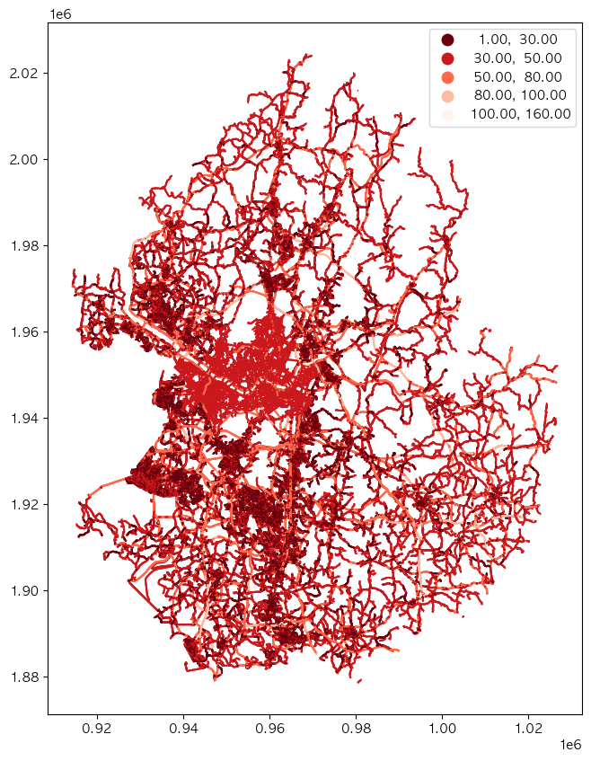

```python
edges_gdf_copy.plot(column='speed', cmap='Reds_r',
               legend=True,
               scheme='UserDefined',
                classification_kwds={'bins': [30, 50, 80, 100]},
                figsize=(10, 10))
```

```python
print(edges_gdf_copy.index.is_unique) # u, v, key 쌍이 중복된 것이 있으면 안되는데 중복이 존재
```

```
False
```

```python
# 인덱스 해제
edges_gdf_copy = edges_gdf_copy.reset_index()

# (u, v) 조합별로 0, 1, 2, ... 순차적으로 key 부여
edges_gdf_copy['key'] = edges_gdf_copy.groupby(['u', 'v']).cumcount()

# 다시 MultiIndex로 설정
edges_gdf_copy = edges_gdf_copy.set_index(['u', 'v', 'key'])
```

```python
print(edges_gdf_copy.index.is_unique)
```

```
True
```

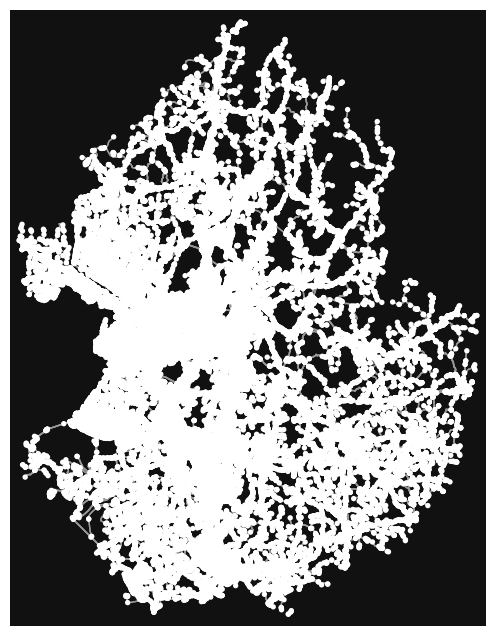

```
(<Figure size 800x800 with 1 Axes>, <Axes: >)
```

```python
G = ox.graph_from_gdfs(nodes_gdf, edges_gdf_copy)

ox.plot_graph(G)
```

```python
list(nx.strongly_connected_components(G))
```

[output not shown]

[output cut: 1998 more lines]

[output not shown]

```python
abc = [c for c in sorted(nx.strongly_connected_components(G), key=len, reverse=True)]
abc
```

[output not shown]

[output cut: 1998 more lines]

[output not shown]

```python
nodes_gdf.loc[nodes_gdf.index.isin(abc[4])].explore()
```

Make this Notebook Trusted to load map: File -> Trust Notebook

[interactive chart not shown]

```python
largest_section = max(nx.strongly_connected_components(G), key=len)
largest_section
```

[output not shown]

[output cut: 946 more lines]

[output not shown]

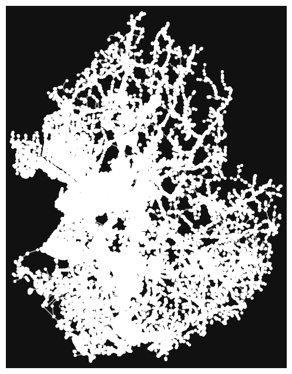

```
(<Figure size 800x800 with 1 Axes>, <Axes: >)
```

```python
# G.subgraph will clip the graph with the nodes provided
# This will create a new graph with only the nodes in the largest section
G = G.subgraph(largest_section)
ox.plot_graph(G)
```

```python
# You can save the graph to a file
ox.save_graphml(G, './data/네트워크분석/road_network_서울경기.graphml')
```

## 5-2. 네트워크 분석을 통한 신설노선 생성

대표 : 클러스터0

```python
cluster_0 = gpd.read_file('./data/클러스터0_최종정류장.geojson')
cluster_0
```

|  | 정류장아이디 | 정류장명 | Y좌표 | X좌표 | index_right | SPO_NO_CD | 8_평균 | breaks | lon | lat | cluster | 예상수요량 | sub_cluster | subway_dist_km | score | geometry |
| --- | --- | --- | --- | --- | --- | --- | --- | --- | --- | --- | --- | --- | --- | --- | --- | --- |
| 0 | 228001733 | 새터마을5단지 | 210642.71326 | 425517.58959 | 54 | 다사66a25b | 12.140973 | 3 | 127.119032 | 37.330141 | 0 | 0.752755 | 0 | 0.467051 | 1.453332 | POINT (127.12088 37.33162) |
| 1 | 228001047 | LG빌리지2차.두산기술원 | 206868.37637 | 423361.56335 | 26 | 다사62b23b | 11.473907 | 3 | 127.079625 | 37.311980 | 0 | 0.677380 | 1 | 1.000000 | 2.177380 | POINT (127.07827 37.31223) |
| 2 | 206000716 | 동원동입구 | 208854.69537 | 426993.40679 | 23 | 다사64b27a | 11.695185 | 3 | 127.102029 | 37.343606 | 0 | 0.019000 | 2 | 0.301694 | 0.471542 | POINT (127.10072 37.34494) |
| 3 | 228000940 | 극동아파트.정평초교 | 207815.12461 | 424418.08145 | 70 | 다사63b24b | 16.462475 | 3 | 127.090861 | 37.321033 | 0 | 0.714804 | 3 | 0.600970 | 1.616259 | POINT (127.08896 37.32174) |
| 4 | 228001053 | 풍덕천사거리 | 208876.70546 | 424607.07292 | 3 | 다사64b25a | 17.703600 | 3 | 127.102124 | 37.325578 | 0 | 0.913986 | 4 | 0.159628 | 1.153428 | POINT (127.10094 37.32343) |

```python
cluster_0.explore() # 정류장 순서(인덱스 기준) : 1 - 3 - 4 - 0 - 2
```

Make this Notebook Trusted to load map: File -> Trust Notebook

[interactive chart not shown]

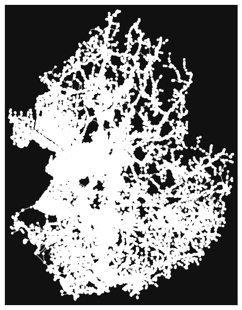

```
(<Figure size 800x800 with 1 Axes>, <Axes: >)
```

```python
G = ox.load_graphml('./data/네트워크분석/road_network_서울경기.graphml')
ox.plot_graph(G)
```

```python
nodes, edges = ox.graph_to_gdfs(G, nodes=True, edges=True)
nodes.head(3) # 판교KT빌딩 노드 = 20231737
```

| osmid | node_type | x | y | geometry |
| --- | --- | --- | --- | --- |
| 20230843 | 101 | 981777.442557 | 1.969712e+06 | POINT (981777.443 1969712.307) |
| 20230847 | 101 | 981648.019337 | 1.969858e+06 | POINT (981648.019 1969857.834) |
| 20230799 | 101 | 970063.471388 | 1.978932e+06 | POINT (970063.471 1978931.902) |

```python
cluster_0.crs
```

```
<Geographic 2D CRS: EPSG:4326>
Name: WGS 84
Axis Info [ellipsoidal]:
- Lat[north]: Geodetic latitude (degree)
- Lon[east]: Geodetic longitude (degree)
Area of Use:
- name: World.
- bounds: (-180.0, -90.0, 180.0, 90.0)
Datum: World Geodetic System 1984 ensemble
- Ellipsoid: WGS 84
- Prime Meridian: Greenwich
```

```python
nodes.crs
```

```
<Projected CRS: PROJCS["ITRF_2000_UTM_K",GEOGCS["ITRF2000",DATUM[" ...>
Name: ITRF_2000_UTM_K
Axis Info [cartesian]:
- [east]: Easting (metre)
- [north]: Northing (metre)
Area of Use:
- undefined
Coordinate Operation:
- name: unnamed
- method: Transverse Mercator
Datum: International Terrestrial Reference Frame 2000
- Ellipsoid: GRS 1980
- Prime Meridian: Greenwich
```

```python
# cluster_0의 CRS를 G에 맞춰 재투영
cluster_0_proj = cluster_0.to_crs(G.graph['crs'])
```

```python
cluster_0_proj['nearest_nodes'] = ox.distance.nearest_nodes(G, cluster_0_proj.geometry.x, cluster_0_proj.geometry.y) # 각 정류장에서 가장 가까운 노드 찾기
cluster_0_proj
```

|  | 정류장아이디 | 정류장명 | Y좌표 | X좌표 | index_right | SPO_NO_CD | 8_평균 | breaks | lon | lat | cluster | 예상수요량 | sub_cluster | subway_dist_km | score | geometry | nearest_nodes |
| --- | --- | --- | --- | --- | --- | --- | --- | --- | --- | --- | --- | --- | --- | --- | --- | --- | --- |
| 0 | 228001733 | 새터마을5단지 | 210642.71326 | 425517.58959 | 54 | 다사66a25b | 12.140973 | 3 | 127.119032 | 37.330141 | 0 | 0.752755 | 0 | 0.467051 | 1.453332 | POINT (966414.218 1925913.385) | 334198 |
| 1 | 228001047 | LG빌리지2차.두산기술원 | 206868.37637 | 423361.56335 | 26 | 다사62b23b | 11.473907 | 3 | 127.079625 | 37.311980 | 0 | 0.677380 | 1 | 1.000000 | 2.177380 | POINT (962630.05 1923778.138) | 334884 |
| 2 | 206000716 | 동원동입구 | 208854.69537 | 426993.40679 | 23 | 다사64b27a | 11.695185 | 3 | 127.102029 | 37.343606 | 0 | 0.019000 | 2 | 0.301694 | 0.471542 | POINT (964634.715 1927398.031) | 336560 |
| 3 | 228000940 | 극동아파트.정평초교 | 207815.12461 | 424418.08145 | 70 | 다사63b24b | 16.462475 | 3 | 127.090861 | 37.321033 | 0 | 0.714804 | 3 | 0.600970 | 1.616259 | POINT (963581.984 1924829.236) | 332231 |
| 4 | 228001053 | 풍덕천사거리 | 208876.70546 | 424607.07292 | 3 | 다사64b25a | 17.703600 | 3 | 127.102124 | 37.325578 | 0 | 0.913986 | 4 | 0.159628 | 1.153428 | POINT (964644.129 1925012.553) | 331667 |

```python
cluster_0_proj['nearest_nodes'] # 1 - 3 - 4 - 0 - 2 - 판교KT빌딩 노드(20231737)
```

```
0    334198
1    334884
2    336560
3    332231
4    331667
Name: nearest_nodes, dtype: int64
```

```python
order = [1, 3, 4, 0, 2] # 정류장 순서 인덱스
node_list = [] # 노드 담을 빈 리스트

for i in order:
    node = cluster_0_proj.iloc[i, 16]
    node_list.append(node)

node_list.append(20231737) # 마지막 판교 kt빌딩 노드 리스트에 추가
node_list
```

```
[334884, 332231, 331667, 334198, 336560, 20231737]
```

```python
# 경로별 edge 추출 리스트 초기화
all_route_edges = []

# 노드 쌍별 최단시간 경로 계산
for i in range(len(node_list)-1):
    origin = node_list[i]
    dest = node_list[i+1]

    # 최단 시간 경로 (노드 리스트)
    route_time = nx.shortest_path(G, origin, dest, weight='travel_time')

    # 노드 쌍으로 edge 리스트 만들기
    od_pairs = [(route_time[j], route_time[j+1]) for j in range(len(route_time)-1)]

    # edge 추출 (edge key는 보통 0)
    od_edges = edges.loc[[(u, v, 0) for u, v in od_pairs]]

    # 리스트에 추가
    all_route_edges.append(od_edges)

# 모든 경로 edge 합치기
route_time_gdf = gpd.GeoDataFrame(pd.concat(all_route_edges), crs=edges.crs)
```

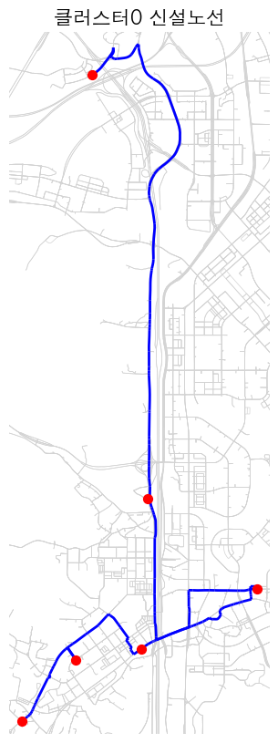

```python
# 시각화
fig, ax = plt.subplots(figsize=(10, 10))

# 전체 도로망 그리되, 분석 지역만 보이게 축 제한
edges.plot(ax=ax, color='lightgrey', linewidth=0.5, zorder=1)

# 출발/도착 노드
nodes.loc[node_list].plot(ax=ax, color='red', markersize=50, zorder=3)

# 경로
route_time_gdf.plot(ax=ax, color='blue', linewidth=2, zorder=2)

# 분석 구간 중심으로 보기 - bounding box로 범위 제한
buffer = 200  # 주변 여백(m) — 필요시 조절
minx, miny, maxx, maxy = route_time_gdf.total_bounds
ax.set_xlim(minx - buffer, maxx + buffer)
ax.set_ylim(miny - buffer, maxy + buffer)

# 제목, 스타일
plt.rcParams['font.family'] = 'AppleGothic'
plt.title("클러스터0 신설노선", fontsize=15)
plt.axis('off')
plt.show()
```

```python
import folium

# 지도 생성 (중심좌표 정자동 기준, 확대 12 디폴트)
m = folium.Map(location=[37.3576, 127.12305], zoom_start=12)

# route_time_gdf EPSG:4326으로 변환
route_time_gdf = route_time_gdf.to_crs(epsg=4326)
route_time_gdf.explore(
    m=m,
    name="Shortest Path (Travel Time)",
    style_kwds={"color": "blue", "weight": 5}
)

# 정류장 데이터프레임도 EPSG:4326으로 변환
cluster_0 = cluster_0.to_crs(epsg=4326)

# folium에 정류장 포인트 추가
for _, row in cluster_0.iterrows():
    folium.CircleMarker(
        location=[row.geometry.y, row.geometry.x],
        radius=4,
        color='red',
        fill=True,
        fill_opacity=0.8,
        popup=row['정류장명'] if '정류장명' in row else None
    ).add_to(m)

# 레이어 컨트롤 추가
folium.LayerControl().add_to(m)

# 6. 지도 출력
m
```

Make this Notebook Trusted to load map: File -> Trust Notebook

[interactive chart not shown]